# Effect of Automatic vs Manual transmission on MPG

## Regression models

### Simple Linear Regression

```r
y = cars_mpg$mpg; x = cars_mpg$am; n =length(y)
fit1 = lm(y ~ x)
summary(fit1)
```

```
##
## Call:
## lm(formula = y ~ x)
##
## Residuals:
##     Min      1Q  Median      3Q     Max
## -9.3923 -3.0923 -0.2974  3.2439  9.5077
##
## Coefficients:
##             Estimate Std. Error t value Pr(>|t|)
## (Intercept)   17.147      1.125  15.247 1.13e-15 ***
## xManual        7.245      1.764   4.106 0.000285 ***
## ---
## Signif. codes:  0 '***' 0.001 '**' 0.01 '*' 0.05 '.' 0.1 ' ' 1
##
## Residual standard error: 4.902 on 30 degrees of freedom
## Multiple R-squared:  0.3598, Adjusted R-squared:  0.3385
## F-statistic: 16.86 on 1 and 30 DF,  p-value: 0.000285
```

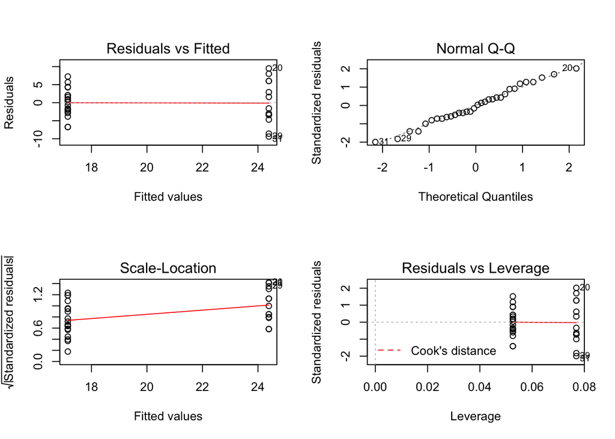

```r
par(mfrow = c(2,2))
plot(fit1)
```

```r
# 95% confidence interval
sumCoef = summary(fit1)$coefficients
sumCoef[2,1] + c(-1, 1) * qt(.975, df = fit1$df) * sumCoef[2, 2]
```

```
## [1]  3.64151 10.84837
```

According to the linear fit coefficients, the average MPG for cars with manual transmission is 7.24 higher than for cars with automatic transmission with a 95% confidence interval of 3.64 and 10.84. The R-squared value of 0.3385 indicates that only 33.9% of the variation is explained by our model.

### Multiple regression

For the multiple regression model only the variable that show a high correlation were chosen in addition to transmission(am). In this case, cyl, disp, hp and wt show the highest correlation. The correlation plot shows that cyl and disp also show a high correalation with each other indicating colinearity. For this reason, only one of the two should be included. cyl will be included in the multiple regression model.

```r
fit2 = lm(mpg ~ wt + cyl + hp + am, data = cars_mpg)
summary(fit2)
```

```
##
## Call:
## lm(formula = mpg ~ wt + cyl + hp + am, data = cars_mpg)
##
## Residuals:
##     Min      1Q  Median      3Q     Max
## -3.9387 -1.2560 -0.4013  1.1253  5.0513
##
## Coefficients:
##             Estimate Std. Error t value Pr(>|t|)
## (Intercept) 33.70832    2.60489  12.940 7.73e-13 ***
## wt          -2.49683    0.88559  -2.819  0.00908 **
## cyl6        -3.03134    1.40728  -2.154  0.04068 *
## cyl8        -2.16368    2.28425  -0.947  0.35225
## hp          -0.03211    0.01369  -2.345  0.02693 *
## amManual     1.80921    1.39630   1.296  0.20646
## ---
## Signif. codes:  0 '***' 0.001 '**' 0.01 '*' 0.05 '.' 0.1 ' ' 1
##
## Residual standard error: 2.41 on 26 degrees of freedom
## Multiple R-squared:  0.8659, Adjusted R-squared:  0.8401
## F-statistic: 33.57 on 5 and 26 DF,  p-value: 1.506e-10
```

```r
anova(fit1,fit2)
```

[output not shown]

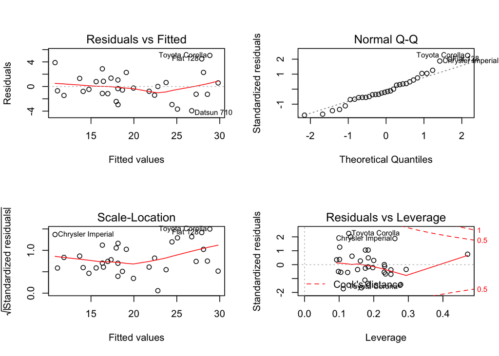

```r
par(mfrow = c(2,2))
plot(fit2)
```

### Apendix - Plots

The box plot below shows a higher over all MPG average for manual transmission compared to automatic transmission.

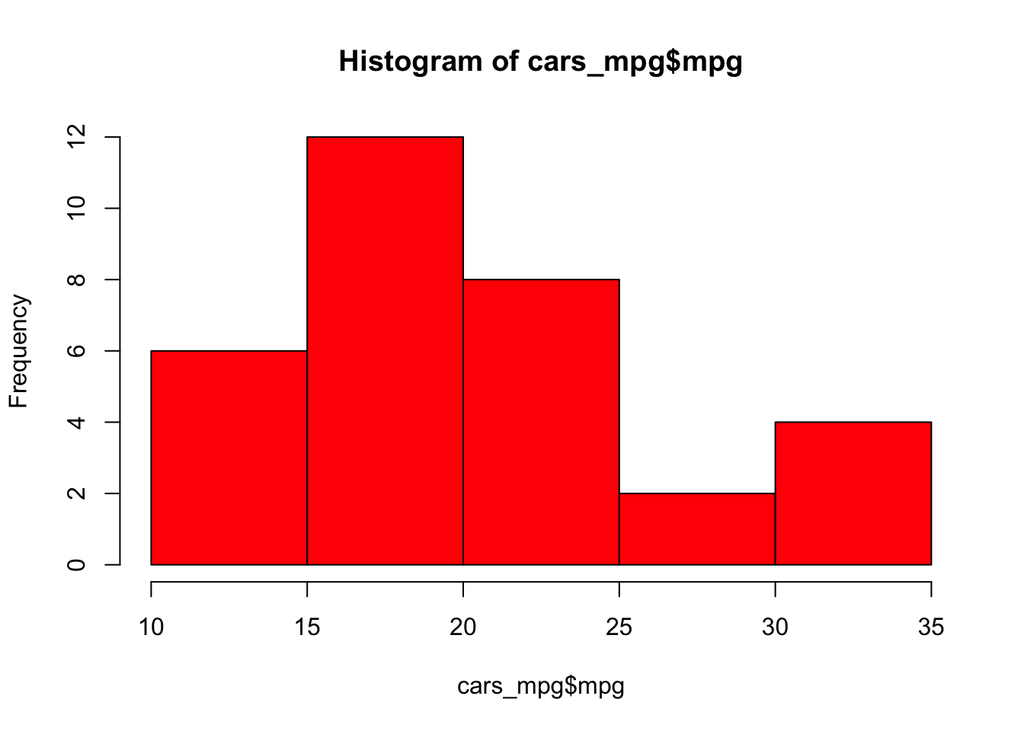

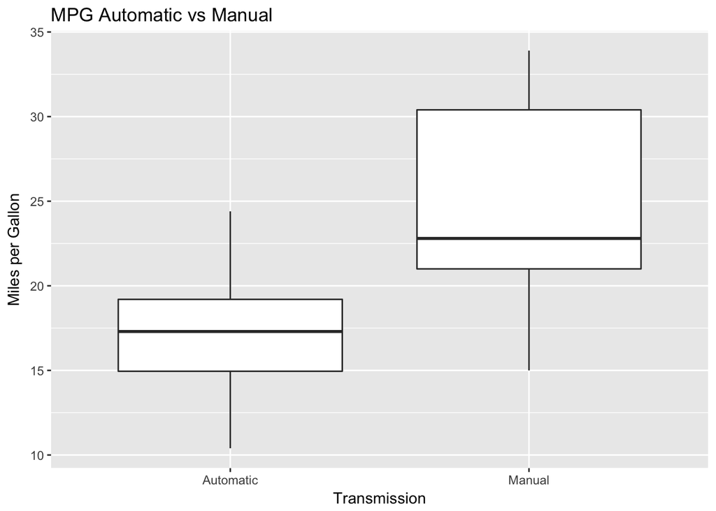

plot 1 clearly shows that with lower number of cylinders, cars with manual transmission have higher MPG. For a higher number of cylinders the transmission doesn’t play much of a roll.  
A similar relationship is seen for displacement, horsepower and weight. With lower horsepower, displacement and weight manual transmission has better MPG performance.  
The opposit relationship is seen for rear axle ratio. When the rear axel ratio is higher, manual transmission hows better MPG performance.

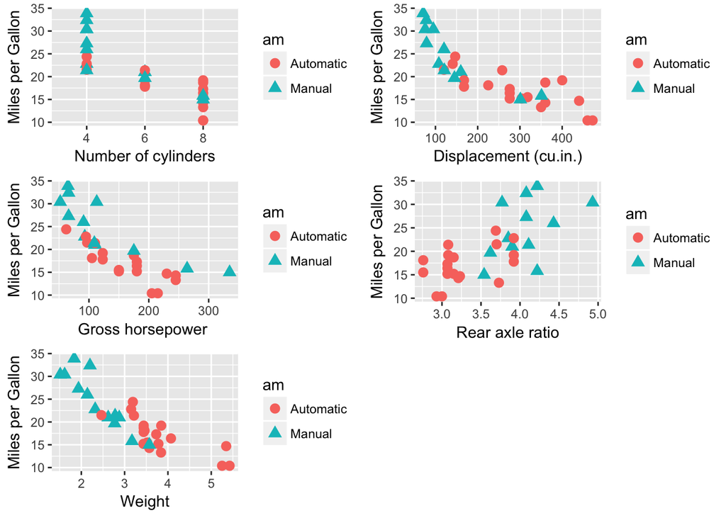

```r
p1 = qplot(cyl, mpg, data=cars_mpg, shape = am, color=am,
      size=I(3),xlab="Number of cylinders", ylab="Miles per Gallon")

p2 = qplot(disp, mpg, data=cars_mpg, shape = am, color=am,
      size=I(3),xlab="Displacement (cu.in.)", ylab="Miles per Gallon")

p3 = qplot(hp, mpg, data=cars_mpg, shape = am, color=am,
      size=I(3),xlab="Gross horsepower ", ylab="Miles per Gallon")

p4 = qplot(drat, mpg, data=cars_mpg, shape = am, color=am,
      size=I(3),xlab="Rear axle ratio", ylab="Miles per Gallon")

p5 = qplot(wt, mpg, data=cars_mpg, shape=am, color=am,
      size=I(3),xlab="Weight", ylab="Miles per Gallon")

grid.arrange(p1, p2, p3, p4, p5)
```

```r
dev.off()
```